## Urban Institute R Graphics Guide

R is a powerful, open-source programming language and environment. R excels at data management and munging, traditional statistical analysis, machine learning, and reproducible research, but it is probably best known for its graphics. This guide contains examples and instructions for popular and lesser-known plotting techniques in R. It also includes instructions for using `urbnthemes`, the Urban Institute’s R package for creating near-publication-ready plots with `ggplot2`. If you have any questions, please don’t hesitate to contact Aaron Williams (awilliams@urban.org) or Kyle Ueyama (kueyama@urban.org).

#### Background

`library(urbnthemes)` makes `ggplot2` output align more closely with [the Urban Institute’s Data Visualization style guide](http://urbaninstitute.github.io/graphics-styleguide/). This package does **not produce publication ready graphics**. Visual styles must still be edited using your project/paper’s normal editing workflow.

The theme has been tested against `ggplot2 version 3.0.0`. It will not function properly with older versions of `ggplot2`

#### Using library(urbnthemes)

Run the following code to install or update `urbnthemes`:

```
install.packages("devtools")
devtools::install_github("UI-Research/urbnthemes")
```

Run the following code at the top of each script:

```
library(tidyverse)
library(urbnthemes)

set_urbn_defaults(style = "print")
```

If it is not already installed, please install the free [Lato font from Google fonts](https://www.google.com/fonts/specimen/Lato). If you’re on Windows, you’ll first need to [install Ghostscript](http://ghostscript.com/download/). You may need to have IT enter an admin password for this installation. Then, in R, tell R where your ghostscript file is. Edit the file path if yours is in a different place

```
Sys.setenv(R_GSCMD="C:/Program Files/gs/gs9.05/bin/gswin32c.exe")
```

Run this script once to import and register Lato:

```
install.packages(c("ggplot2", "ggrepel", "extrafont"))

urbnthemes::lato_install()
```

Loading and importing fonts may take a few minutes.

#### Grammar of Graphics and Conventions

Hadley Wickham’s ggplot2 is based on Leland Wilkinson’s [*The Grammar of Graphics*](https://www.amazon.com/Grammar-Graphics-Statistics-Computing/dp/0387245448) and Wickham’s [*A Layered Grammar of Graphics*](http://vita.had.co.nz/papers/layered-grammar.html). The layered grammar of graphics is a structured way of thinking about the components of a plot, which then lend themselves to the simple structure of ggplot2.

- **Data** are what are visualizaed in a plot and **mappings** are directions for how data are mapped in a plot in a way that can be perceived by humans.
- **Geoms** are representations of the actual data like points, lines, and bars.
- **Stats** are statistical transformations that represent summaries of the data like histograms.
- **Scales** map values in the data space to values in the aesthetic space. Scales draw legends and axes.
- **Coordinate Systems** describe how geoms are mapped to the plane of the graphic.
- **Facets** break the data into meaningful subsets like small multiples.
- **Themes** control the finer points of a plot such as fonts, font sizes, and background colors.

More information: [ggplot2: Elegant Graphics for Data Analysis](https://www.amazon.com/ggplot2-Elegant-Graphics-Data-Analysis/dp/0387981403)

## Bar Plots

### One Color

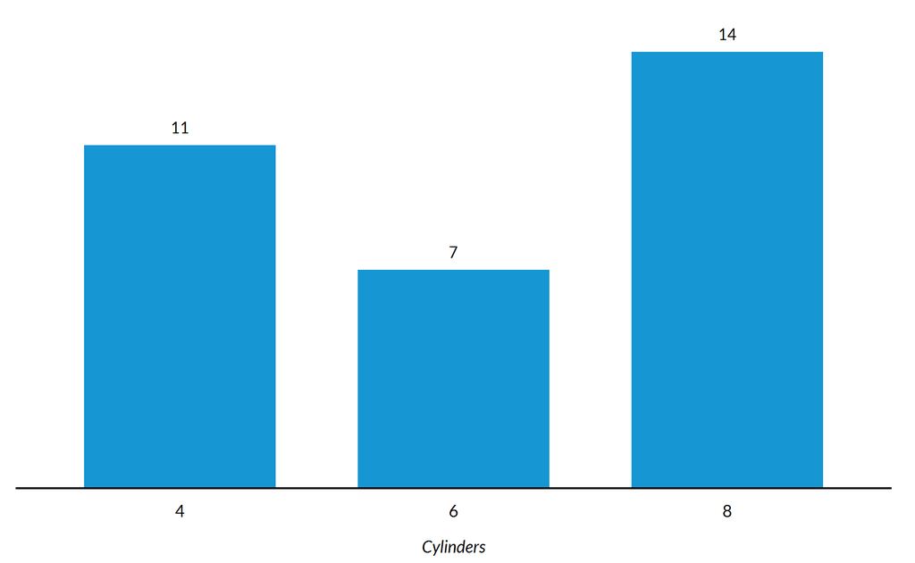

```r
mtcars %>%
  count(cyl) %>%
  ggplot(mapping = aes(x = factor(cyl), y = n)) +
  geom_col() +
  geom_text(mapping = aes(label = n), vjust = -1) +
  scale_y_continuous(expand = expand_scale(mult = c(0, 0.1))) +
  labs(x = "Cylinders",
       y = NULL) +
  remove_ticks() +
  remove_axis()
```

### One Color (Rotated)

This example introduces `coord_flip()` and `remove_axis(axis = "x", flip = TRUE)`. `remove_axis()` is from `library(urbnthemes)` and creates a custom theme for rotated bar plots.

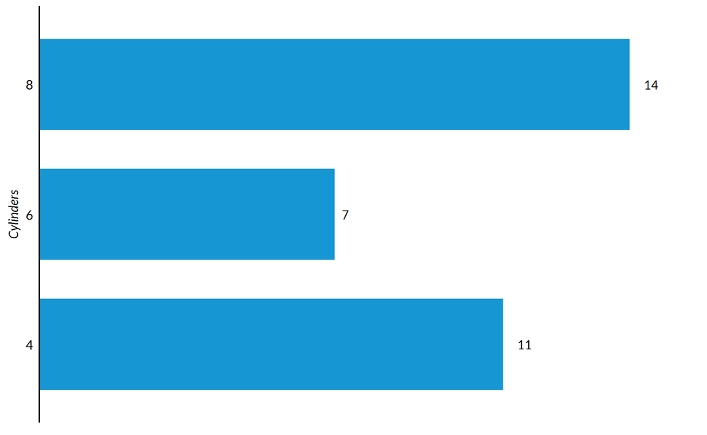

```r
mtcars %>%
  count(cyl) %>%
  ggplot(mapping = aes(x = factor(cyl), y = n)) +
  geom_col() +
  geom_text(mapping = aes(label = n), hjust = -1) +
  scale_y_continuous(expand = expand_scale(mult = c(0, 0.1))) +
  labs(x = "Cylinders",
       y = NULL) +
  coord_flip() +
  remove_axis(axis = "x", flip = TRUE)
```

### Three Colors

This is identical to the previous plot except colors and a legend are added with `fill = cyl`. Turning `x` into a factor with `factor(cyl)` skips 5 and 7 on the `x-axis`. Adding `fill = cyl` without `factor()` would have created a continuous color scheme and legend.

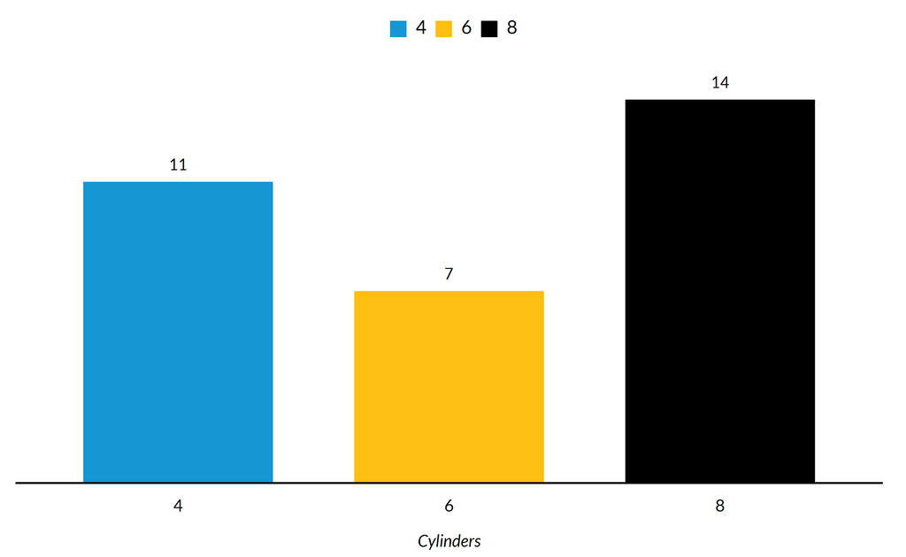

```r
mtcars %>%
  mutate(cyl = factor(cyl)) %>%
  count(cyl) %>%
  ggplot(mapping = aes(x = cyl, y = n, fill = cyl)) +
  geom_col() +
  geom_text(mapping = aes(label = n), vjust = -1) +
  scale_y_continuous(expand = expand_scale(mult = c(0, 0.1))) +
  labs(x = "Cylinders",
       y = NULL) +
  remove_ticks() +
  remove_axis()
```

### Stacked Bar Plot

An additional aesthetic can easily be added to bar plots by adding `fill = categorical variable` to the mapping. Here, transmission type subsets each bar showing the count of cars with different numbers of cylinders.

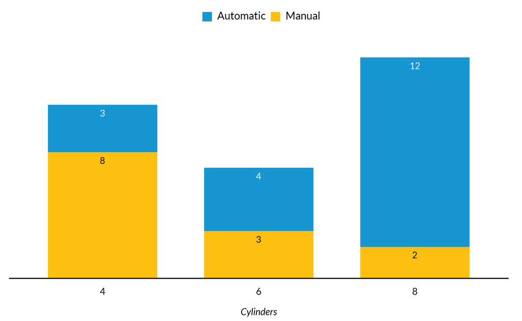

```r
mtcars %>%
  mutate(am = factor(am, labels = c("Automatic", "Manual")),
         cyl = factor(cyl)) %>%
  group_by(am) %>%
  count(cyl) %>%
  group_by(cyl) %>%
  arrange(desc(am)) %>%
  mutate(label_height = cumsum(n)) %>%
  ggplot() +
  geom_col(mapping = aes(x = cyl, y = n, fill = am)) +
  geom_text(aes(x = cyl, y = label_height - 0.5, label = n, color = am)) +
  scale_color_manual(values = c("white", "black")) +
  scale_y_continuous(expand = expand_scale(mult = c(0, 0.1))) +
  labs(x = "Cylinders",
       y = NULL) +
  remove_ticks() +
  remove_axis() +
  guides(color = FALSE)
```

### Stacked Bar Plot With Position = Fill

The previous examples used `geom_col()`, which takes a y value for bar height. This example uses `geom_bar()` which sums the values and generates a value for bar heights. In this example, `position = "fill"` in `geom_bar()` changes the y-axis from count to the proportion of each bar.

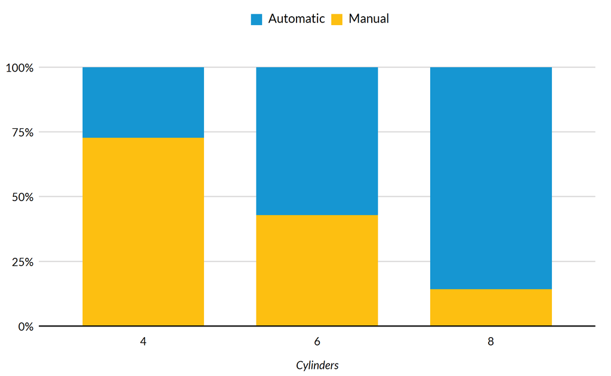

```r
mtcars %>%
  mutate(am = factor(am, labels = c("Automatic", "Manual")),
         cyl = factor(cyl)) %>%
  ggplot() +
  geom_bar(mapping = aes(x = cyl, fill = am), position = "fill") +
  scale_y_continuous(expand = expand_scale(mult = c(0, 0.1)), labels = scales::percent) +
  labs(x = "Cylinders",
       y = NULL) +
  remove_ticks() +
  guides(color = FALSE)
```

### Dodged Bar Plot

Subsetted bar charts in ggplot2 are stacked by default. `position = "dodge"` in `geom_col()` expands the bar chart so the bars appear next to each other.

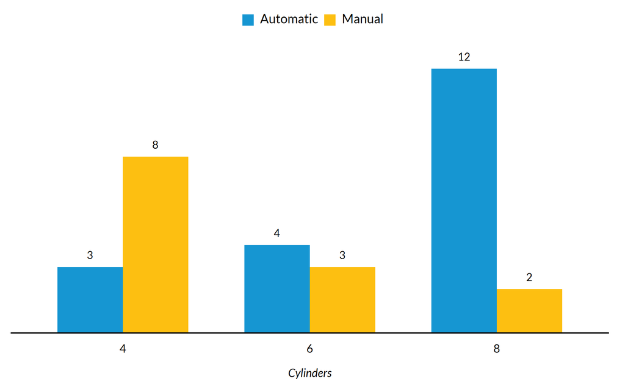

```r
mtcars %>%
  mutate(am = factor(am, labels = c("Automatic", "Manual")),
         cyl = factor(cyl)) %>%
  group_by(am) %>%
  count(cyl) %>%
  ggplot(mapping = aes(cyl, y = n, fill = factor(am))) +
  geom_col(position = "dodge") +
  geom_text(aes(label = n), position = position_dodge(width = 0.7), vjust = -1) +
  scale_y_continuous(expand = expand_scale(mult = c(0, 0.1))) +
  labs(x = "Cylinders",
       y = NULL) +
  remove_ticks() +
  remove_axis()
```

### Lollipop plot/Cleveland dot plot

Lollipop plots and Cleveland dot plots are minimalist alternatives to bar plots. The key to both plots is to order the data based on the continuous variable using `arrange()` and then turn the discrete variable into a factor with the ordered levels of the continuous variable using `mutate()`. This step “stores” the order of the data.

#### Lollipop plot

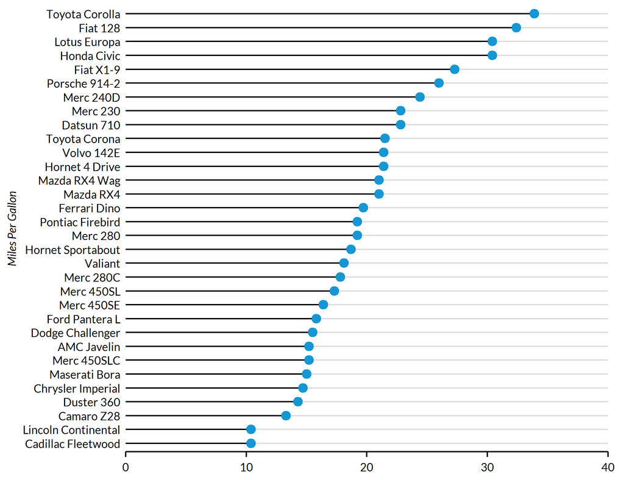

```r
mtcars %>%
  rownames_to_column("model") %>%
  arrange(mpg) %>%
  mutate(model = factor(model, levels = .$model)) %>%
  ggplot(aes(mpg, model)) +
    geom_segment(aes(x = 0, xend = mpg, y = model, yend = model)) +
    geom_point() +
    scale_x_continuous(expand = expand_scale(mult = c(0, 0)), limits = c(0, 40)) +
    labs(x = NULL,
         y = "Miles Per Gallon")
```

#### Cleveland dot plot

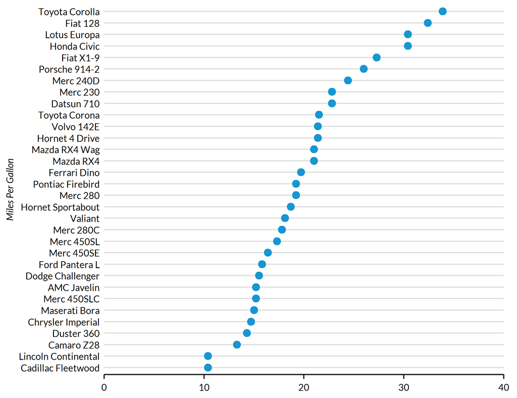

```r
mtcars %>%
  rownames_to_column("model") %>%
  arrange(mpg) %>%
  mutate(model = factor(model, levels = .$model)) %>%
  ggplot(aes(mpg, model)) +
    geom_point() +
    scale_x_continuous(expand = expand_scale(mult = c(0, 0)), limits = c(0, 40)) +
    labs(x = NULL,
         y = "Miles Per Gallon")
```

## Scatter Plots

### One Color Scatter Plot

Scatter plots are useful for showing relationships between two or more variables. Use `scatter_grid()` from `library(urbnthemes)` to easily add vertical grid lines for scatter plots.

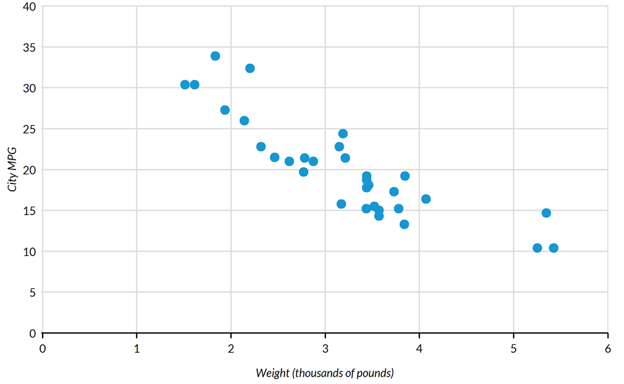

```r
mtcars %>%
  ggplot(mapping = aes(x = wt, y = mpg)) +
  geom_point() +
  scale_x_continuous(expand = expand_scale(mult = c(0.002, 0)),
                     limits = c(0, 6),
                     breaks = 0:6) +
  scale_y_continuous(expand = expand_scale(mult = c(0, 0.002)),
                     limits = c(0, 40),
                     breaks = 0:8 * 5) +
  labs(x = "Weight (thousands of pounds)",
       y = "City MPG") +
  scatter_grid()
```

### High-Density Scatter Plot with Transparency

Large numbers of observations can sometimes make scatter plots tough to interpret because points overlap. Adding `alpha =` with a number between 0 and 1 adds transparency to points and clarity to plots. Now it’s easy to see that jewelry stores are probably rounding up but not rounding down carats!

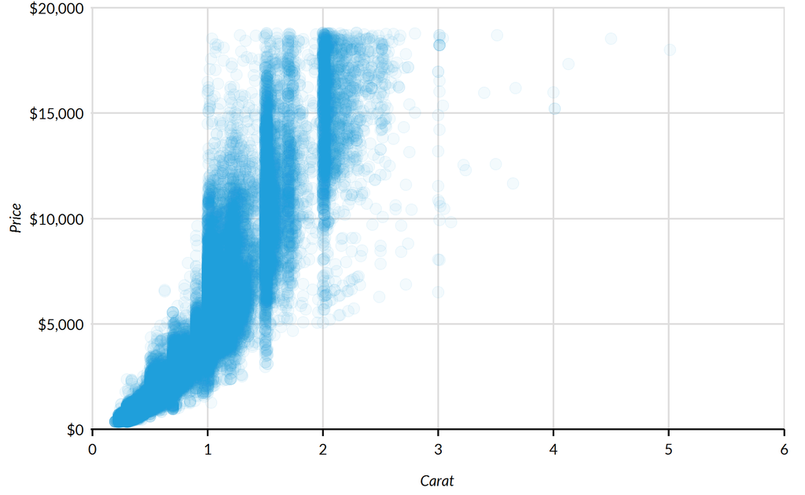

```r
diamonds %>%
  ggplot(mapping = aes(x = carat, y = price)) +
  geom_point(alpha = 0.05) +
  scale_x_continuous(expand = expand_scale(mult = c(0.002, 0)),
                     limits = c(0, 6),
                     breaks = 0:6) +
  scale_y_continuous(expand = expand_scale(mult = c(0, 0.002)),
                     limits = c(0, 20000),
                     breaks = 0:4 * 5000,
                     labels = scales::dollar) +
  labs(x = "Carat",
       y = "Price") +
  scatter_grid()
```

### Hex Scatter Plot

Sometimes transparency isn’t enough to bring clarity to a scatter plot with many observations. As n increases into the hundreds of thousands and even millions, `geom_hex` can be one of the best ways to display relationships between two variables.

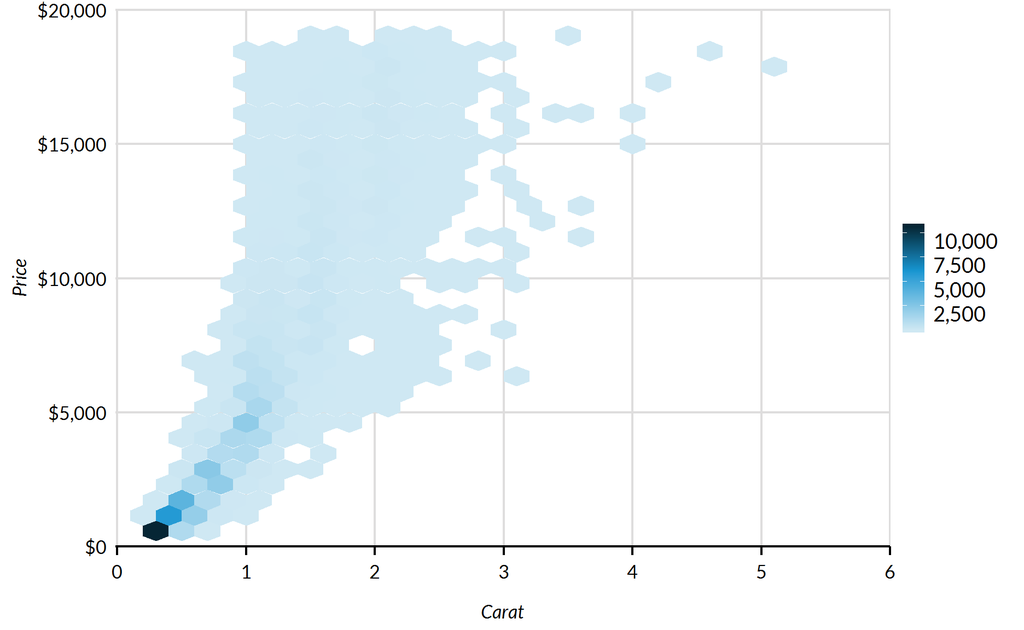

```r
diamonds %>%
  ggplot(mapping = aes(x = carat, y = price)) +
  geom_hex(mapping = aes(fill = ..count..)) +
  scale_x_continuous(expand = expand_scale(mult = c(0.002, 0)),
                     limits = c(0, 6),
                     breaks = 0:6) +
  scale_y_continuous(expand = expand_scale(mult = c(0, 0.002)),
                     limits = c(0, 20000),
                     breaks = 0:4 * 5000,
                     labels = scales::dollar) +
  scale_fill_gradientn(labels = scales::comma) +
  labs(x = "Carat",
       y = "Price") +
  scatter_grid() +
  theme(legend.position = "right",
        legend.direction = "vertical")
```

### Scatter Plots With Random Noise

Sometimes scatter plots have many overlapping points but a reasonable number of observations. `geom_jitter` adds a small amount of random noise so points are less likely to overlap. `width` and `height` control the amount of noise that is added. In the following before-and-after, notice how many more points are visible after adding jitter.

#### Before

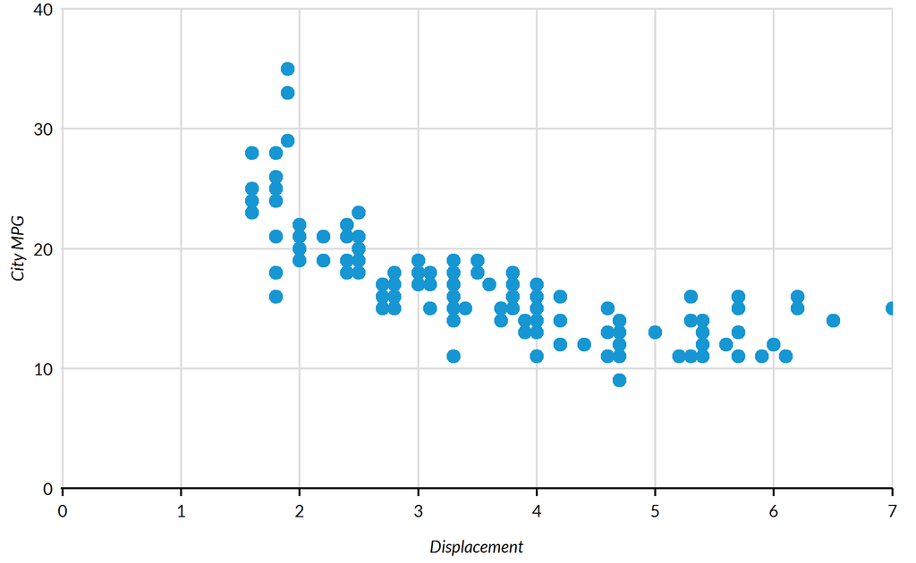

```r
mpg %>%
  ggplot(mapping = aes(x = displ, y = cty)) +
  geom_point() +
  scale_x_continuous(expand = expand_scale(mult = c(0.002, 0)),
                     limits = c(0, 7),
                     breaks = 0:7) +
  scale_y_continuous(expand = expand_scale(mult = c(0, 0.002)),
                     limits = c(0, 40),
                     breaks = 0:4 * 10) +
  labs(x = "Displacement",
       y = "City MPG") +
  scatter_grid()
```

#### After

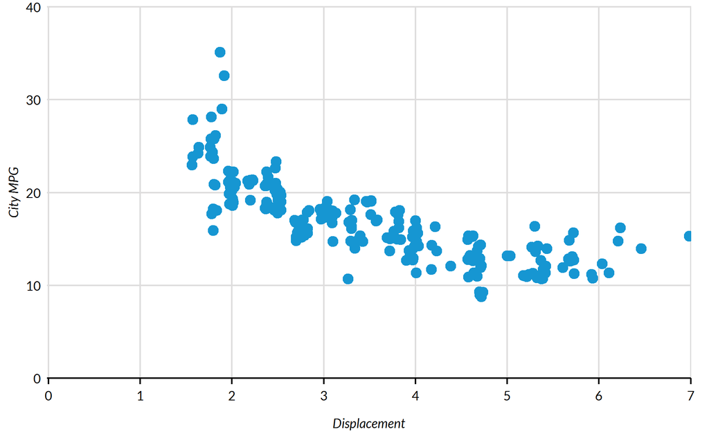

```r
set.seed(2017)
mpg %>%
  ggplot(mapping = aes(x = displ, y = cty)) +
  geom_jitter() +
  scale_x_continuous(expand = expand_scale(mult = c(0.002, 0)),
                     limits = c(0, 7),
                     breaks = 0:7) +
  scale_y_continuous(expand = expand_scale(mult = c(0, 0.002)),
                     limits = c(0, 40),
                     breaks = 0:4 * 10) +
  labs(x = "Displacement",
       y = "City MPG") +
  scatter_grid()
```

### Scatter Plots with Varying Point Size

Weights and populations can be mapped in scatter plots to the size of the points. Here, the number of households in each state is mapped to the size of each point using `aes(size = hhpop)`. Note: `ggplot2::geom_point()` is used instead of `geom_point()`.

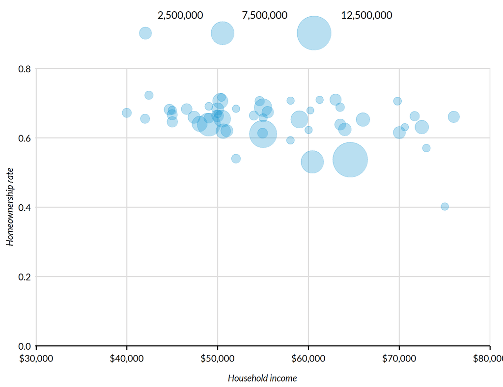

```r
urbnmapr::statedata %>%
  ggplot(mapping = aes(x = medhhincome, y = horate)) +
  ggplot2::geom_point(mapping = aes(size = hhpop), alpha = 0.3) +
  scale_x_continuous(expand = expand_scale(mult = c(0.002, 0)),
                     limits = c(30000, 80000),
                     breaks = 3:8 * 10000,
                     labels = scales::dollar) +
  scale_y_continuous(expand = expand_scale(mult = c(0, 0.002)),
                     limits = c(0, 0.8),
                     breaks = 0:4 * 0.2) +
  scale_radius(range = c(3, 15),
               breaks = c(2500000, 7500000, 12500000),
               labels = scales::comma) +
  labs(x = "Household income",
       y = "Homeownership rate") +
  scatter_grid()
```

### Scatter Plots with Fill

A third aesthetic can be added to scatter plots. Here, color signifies the number of cylinders in each car. Before `ggplot()` is called, Cylinders is created using `library(dplyr)` and the piping operator `%>%`.

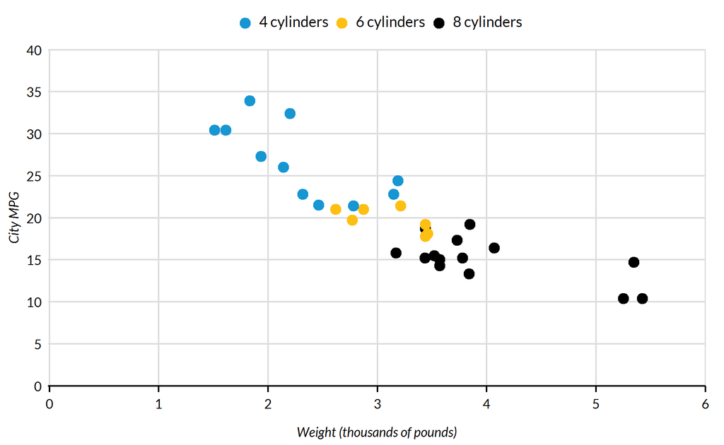

```r
mtcars %>%
  mutate(cyl = paste(cyl, "cylinders")) %>%
  ggplot(aes(x = wt, y = mpg, color = cyl)) +
  geom_point() +
  scale_x_continuous(expand = expand_scale(mult = c(0.002, 0)),
                     limits = c(0, 6),
                     breaks = 0:6) +
  scale_y_continuous(expand = expand_scale(mult = c(0, 0.002)),
                     limits = c(0, 40),
                     breaks = 0:8 * 5) +
  labs(x = "Weight (thousands of pounds)",
       y = "City MPG") +
  scatter_grid()
```

## Line Plots

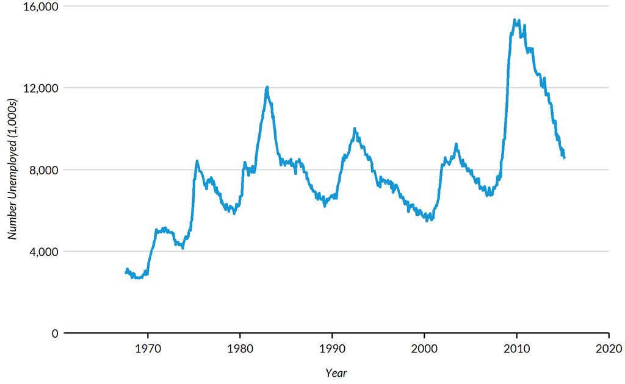

```r
economics %>%
  ggplot(mapping = aes(x = date, y = unemploy)) +
  geom_line() +
  scale_x_date(expand = expand_scale(mult = c(0.002, 0)),
               breaks = "10 years",
               limits = c(as.Date("1961-01-01"), as.Date("2020-01-01")),
               date_labels = "%Y") +
  scale_y_continuous(expand = expand_scale(mult = c(0, 0.002)),
                     breaks = 0:4 * 4000,
                     limits = c(0, 16000),
                     labels = scales::comma) +
  labs(x = "Year",
       y = "Number Unemployed (1,000s)")
```

### Lines Plots With Multiple Lines

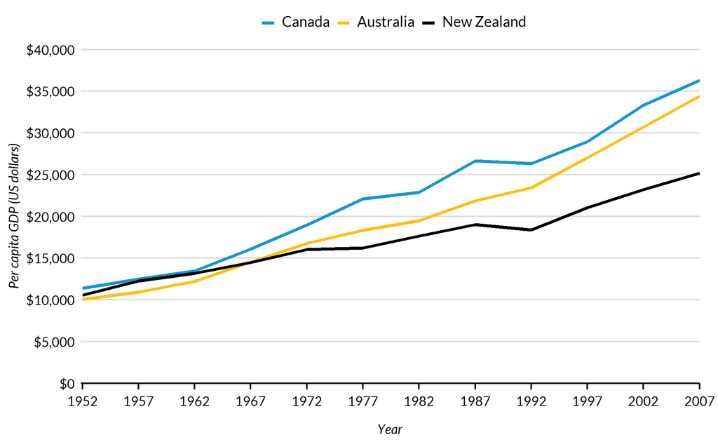

```r
library(gapminder)

gapminder %>%
  filter(country %in% c("Australia", "Canada", "New Zealand")) %>%
  mutate(country = factor(country, levels = c("Canada", "Australia", "New Zealand"))) %>%
  ggplot(aes(year, gdpPercap, color = country)) +
  geom_line() +
  scale_x_continuous(expand = expand_scale(mult = c(0.002, 0)),
                     breaks = c(1952 + 0:12 * 5),
                     limits = c(1952, 2007)) +
  scale_y_continuous(expand = expand_scale(mult = c(0, 0.002)),
                     breaks = 0:8 * 5000,
                     labels = scales::dollar,
                     limits = c(0, 40000)) +
  labs(x = "Year",
       y = "Per capita GDP (US dollars)")
```

Plotting more than one variable can be useful for seeing the relationship of variables over time, but it takes a small amount of data munging.

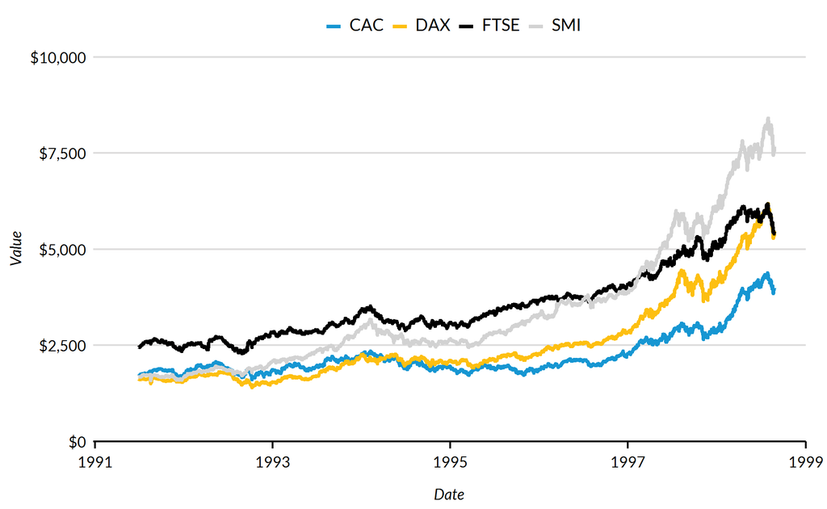

```r
as_tibble(EuStockMarkets) %>%
  mutate(date = time(EuStockMarkets)) %>%
  gather(key = "key", value = "value", -date) %>%
  ggplot(mapping = aes(x = date, y = value, color = key)) +
  geom_line() +
  scale_x_continuous(expand = expand_scale(mult = c(0.002, 0)),
                     limits = c(1991, 1999),
                     breaks = c(1991, 1993, 1995, 1997, 1999)) +
  scale_y_continuous(expand = expand_scale(mult = c(0, 0.002)),
                     breaks = 0:4 * 2500,
                     labels = scales::dollar,
                     limits = c(0, 10000)) +
  labs(x = "Date",
       y = "Value")
```

### Step plot

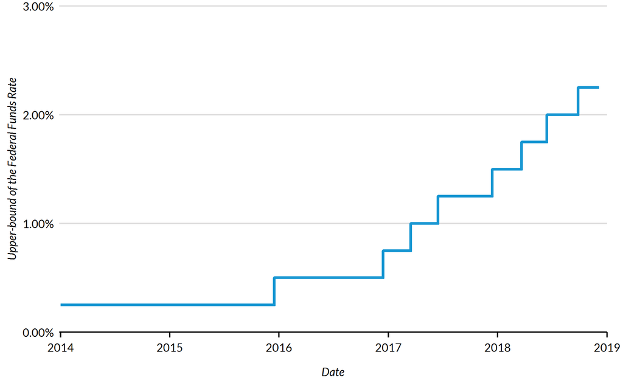

```r
# downloaded from FRED on 2018-12-06

# https://fred.stlouisfed.org/series/DFEDTARU

fed_fund_rate <- read_csv(
  "date, fed_funds_rate
   2014-01-01,0.0025
   2015-12-16,0.0050
   2016-12-14,0.0075
   2017-03-16,0.0100
   2017-06-15,0.0125
   2017-12-14,0.0150
   2018-03-22,0.0175
   2018-06-14,0.0200
   2018-09-27,0.0225
   2018-12-06,0.0225")

fed_fund_rate %>%
  ggplot(mapping = aes(x = date, y = fed_funds_rate)) +
  geom_step() +
  scale_x_date(expand = expand_scale(mult = c(0.002, 0)),
               breaks = "1 year",
               limits = c(as.Date("2014-01-01"), as.Date("2019-01-01")),
               date_labels = "%Y") +
  scale_y_continuous(expand = expand_scale(mult = c(0, 0.002)),
                     breaks = c(0, 0.01, 0.02, 0.03),
                     limits = c(0, 0.03),
                     labels = scales::percent) +
  labs(x = "Date",
       y = "Upper-bound of the Federal Funds Rate")
```

### Path plot

The Beveridge curve is a macroeconomic plot that displays a relationship between the unemployment rate and the vacancy rate. Movements along the curve indicate changes in the business cyle and horizontal shifts of the curve suggest structural changes in the labor market.

Lines in Beveridge curves do not monotonically move from left to right. Therefore, it is necessary to use `geom_path()`.

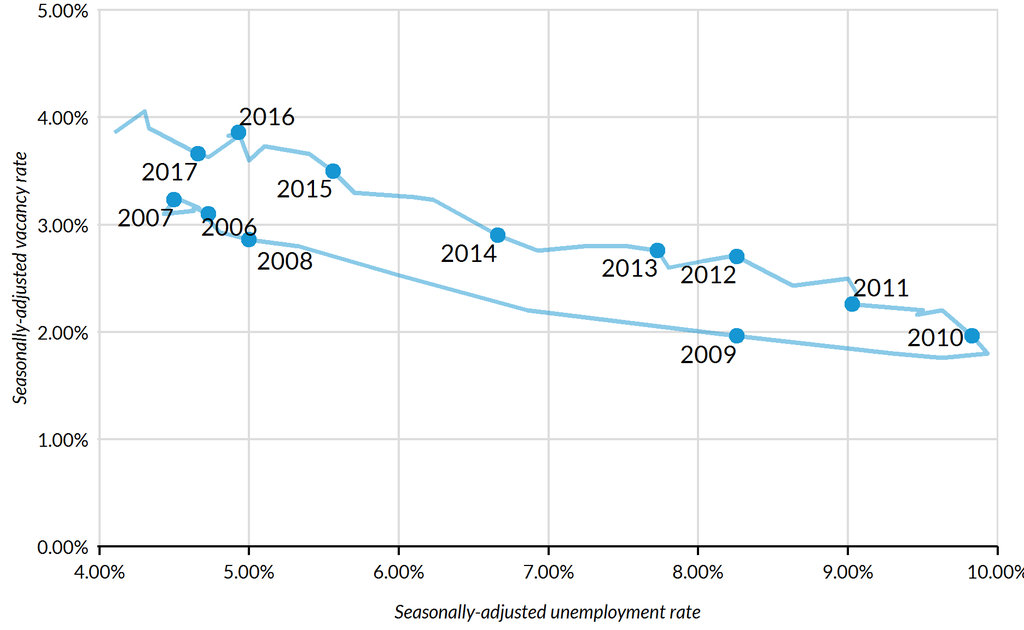

```r
# seasonally-adjusted, quarterly vacancy rate - JOLTS # seasonally-adjusted, quarterly unemployment rate - CPS

# pulled from FRED on April 11, 2018.

library(ggrepel)

beveridge <- read_csv(
  "quarter, vacanacy_rate, unempoyment_rate
  2006-01-01,0.0310,0.0473
  2006-04-01,0.0316,0.0463
  2006-07-01,0.0313,0.0463
  2006-10-01,0.0310,0.0443
  2007-01-01,0.0323,0.0450
  2007-04-01,0.0326,0.0450
  2007-07-01,0.0316,0.0466
  2007-10-01,0.0293,0.0480
  2008-01-01,0.0286,0.0500
  2008-04-01,0.0280,0.0533
  2008-07-01,0.0253,0.0600
  2008-10-01,0.0220,0.0686
  2009-01-01,0.0196,0.0826
  2009-04-01,0.0180,0.0930
  2009-07-01,0.0176,0.0963
  2009-10-01,0.0180,0.0993
  2010-01-01,0.0196,0.0983
  2010-04-01,0.0220,0.0963
  2010-07-01,0.0216,0.0946
  2010-10-01,0.0220,0.0950
  2011-01-01,0.0226,0.0903
  2011-04-01,0.0236,0.0906
  2011-07-01,0.0250,0.0900
  2011-10-01,0.0243,0.0863
  2012-01-01,0.0270,0.0826
  2012-04-01,0.0270,0.0820
  2012-07-01,0.0266,0.0803
  2012-10-01,0.0260,0.0780
  2013-01-01,0.0276,0.0773
  2013-04-01,0.0280,0.0753
  2013-07-01,0.0280,0.0723
  2013-10-01,0.0276,0.0693
  2014-01-01,0.0290,0.0666
  2014-04-01,0.0323,0.0623
  2014-07-01,0.0326,0.0610
  2014-10-01,0.0330,0.0570
  2015-01-01,0.0350,0.0556
  2015-04-01,0.0366,0.0540
  2015-07-01,0.0373,0.0510
  2015-10-01,0.0360,0.0500
  2016-01-01,0.0386,0.0493
  2016-04-01,0.0383,0.0486
  2016-07-01,0.0383,0.0493
  2016-10-01,0.0363,0.0473
  2017-01-01,0.0366,0.0466
  2017-04-01,0.0390,0.0433
  2017-07-01,0.0406,0.0430
  2017-10-01,0.0386,0.0410")

labels <- beveridge %>%
  filter(lubridate::month(quarter) == 1)

beveridge %>%
  ggplot() +
  geom_path(mapping = aes(x = unempoyment_rate, y = vacanacy_rate), alpha = 0.5) +
  geom_point(data = labels, mapping = aes(x = unempoyment_rate, y = vacanacy_rate)) +
  geom_text_repel(data = labels, mapping = aes(x = unempoyment_rate, y = vacanacy_rate, label = lubridate::year(quarter))) +
  scale_x_continuous(expand = expand_scale(mult = c(0.002, 0)),
                     limits = c(0.04, 0.1),
                     labels = scales::percent) +
  scale_y_continuous(expand = expand_scale(mult = c(0, 0.002)),
                     breaks = c(0, 0.01, 0.02, 0.03, 0.04, 0.05),
                     limits = c(0, 0.05),
                     labels = scales::percent) +
  labs(x = "Seasonally-adjusted unemployment rate",
       y = "Seasonally-adjusted vacancy rate") +
  scatter_grid()
```

### Slope plots

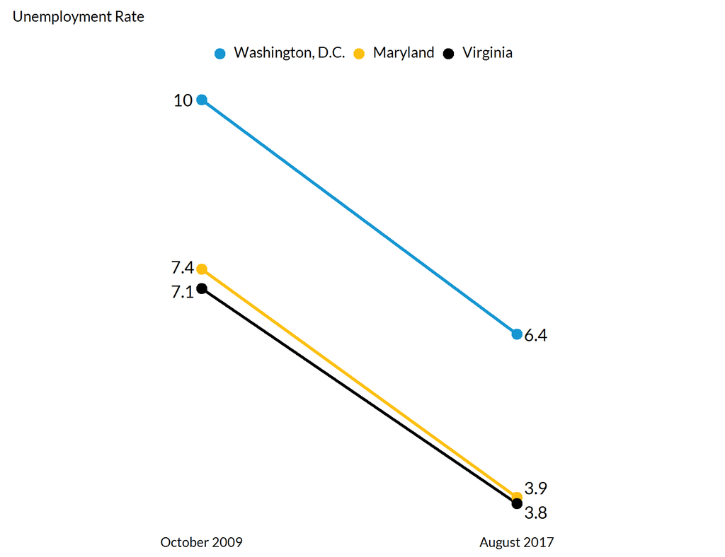

```r
# https://www.bls.gov/lau/
library(ggrepel)

unemployment <- tibble(
  time = c("October 2009", "October 2009", "October 2009", "August 2017", "August 2017", "August 2017"),
  rate = c(7.4, 7.1, 10.0, 3.9, 3.8, 6.4),
  state = c("Maryland", "Virginia", "Washington, D.C.", "Maryland", "Virginia", "Washington, D.C.")
)

label <- tibble(label = c("October 2009", "August 2017"))
october <- filter(unemployment, time == "October 2009")
august <- filter(unemployment, time == "August 2017")

unemployment %>%
  mutate(time = factor(time, levels = c("October 2009", "August 2017")),
         state = factor(state, levels = c("Washington, D.C.", "Maryland", "Virginia"))) %>%
  ggplot() +
  geom_line(aes(time, rate, group = state, color = state), show.legend = FALSE) +
  geom_point(aes(x = time, y = rate, color = state)) +
  labs(subtitle = "Unemployment Rate") +
  theme(axis.ticks.x = element_blank(),
        axis.title.x = element_blank(),
        axis.ticks.y = element_blank(),
        axis.title.y = element_blank(),
        axis.text.y = element_blank(),
        panel.grid.major.y = element_blank(),
        panel.grid.minor.y = element_blank(),
        panel.grid.major.x = element_blank(),
        axis.line = element_blank()) +
  geom_text_repel(data = october, mapping = aes(x = time, y = rate, label = as.character(rate)), nudge_x = -0.06) +
  geom_text_repel(data = august, mapping = aes(x = time, y = rate, label = as.character(rate)), nudge_x = 0.06)
```

## Univariate

There are a number of ways to explore the distributions of univariate data in R. Some methods, like strip charts, show all data points. Other methods, like the box and whisker plot, show selected data points that communicate key values like the median and 25th percentile. Finally, some methods don’t show any of the underlying data but calculate density estimates. Each method has advantages and disadvantages, so it is worthwhile to understand the different forms. For more information, read [40 years of boxplots](http://vita.had.co.nz/papers/boxplots.pdf) by Hadley Wickham and Lisa Stryjewski.

### Strip Chart

Strip charts, the simplest univariate plot, show the distribution of values along one axis. Strip charts work best with variables that have plenty of variation. If not, the points tend to cluster on top of each other. Even if the variable has plenty of variation, it is often important to add transparency to the points with `alpha =` so overlapping values are visible.

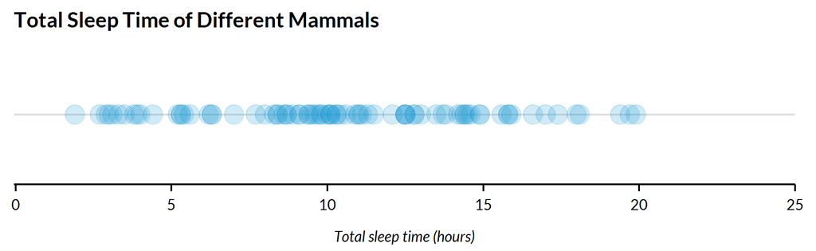

```r
msleep %>%
  ggplot(aes(x = sleep_total, y = factor(1))) +
  geom_point(alpha = 0.2, size = 5) +
  labs(y = NULL) +
  scale_x_continuous(expand = expand_scale(mult = c(0.002, 0)),
                     limits = c(0, 25),
                     breaks = 0:5 * 5) +
  scale_y_discrete(labels = NULL) +
  labs(title = "Total Sleep Time of Different Mammals",
       x = "Total sleep time (hours)",
       y = NULL) +
  theme(axis.ticks.y = element_blank())
```

### Strip Chart with Highlighting

Because strip charts show all values, they are useful for showing where selected points lie in the distribution of a variable. The clearest way to do this is by adding `geom_point()` twice with `filter()` in the data argument. This way, the highlighted values show up on top of unhighlighted values.

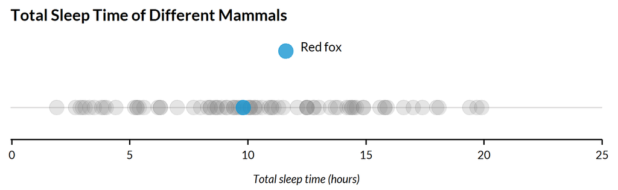

```r
ggplot() +
  geom_point(data = filter(msleep, name != "Red fox"),
                    aes(x = sleep_total,
                        y = factor(1)),
             alpha = 0.2,
             size = 5,
             color = "grey50") +
  geom_point(data = filter(msleep, name == "Red fox"),
             aes(x = sleep_total,
                 y = factor(1),
                 color = name),
             alpha = 0.8,
             size = 5) +
  scale_x_continuous(expand = expand_scale(mult = c(0.002, 0)),
                     limits = c(0, 25),
                     breaks = 0:5 * 5) +
  scale_y_discrete(labels = NULL) +
  labs(title = "Total Sleep Time of Different Mammals",
       x = "Total sleep time (hours)",
       y = NULL,
       legend) +
  guides(color = guide_legend(title = NULL)) +
  theme(axis.ticks.y = element_blank())
```

### Subsetted Strip Chart

Add a y variable to see the distributions of the continuous variable in subsets of a categorical variable.

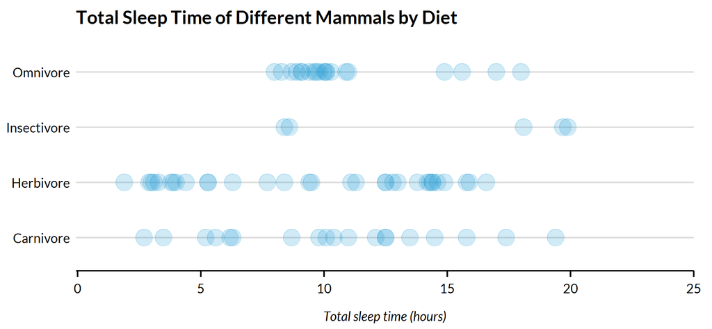

```r
library(forcats)

msleep %>%
  filter(!is.na(vore)) %>%
  mutate(vore = fct_recode(vore,
                            "Insectivore" = "insecti",
                            "Omnivore" = "omni",
                            "Herbivore" = "herbi",
                            "Carnivore" = "carni"
                            )) %>%
  ggplot(aes(x = sleep_total, y = vore)) +
  geom_point(alpha = 0.2, size = 5) +
  scale_x_continuous(expand = expand_scale(mult = c(0.002, 0)),
                     limits = c(0, 25),
                     breaks = 0:5 * 5) +
  labs(title = "Total Sleep Time of Different Mammals by Diet",
       x = "Total sleep time (hours)",
       y = NULL) +
  theme(axis.ticks.y = element_blank())
```

### Histograms

Histograms divide the distribution of a variable into n equal-sized bins and then count and display the number of observations in each bin. Histograms are sensitive to bin width. As `?geom_histogram` notes, “You should always override [the default binwidth] value, exploring multiple widths to find the best to illustrate the stories in your data.”

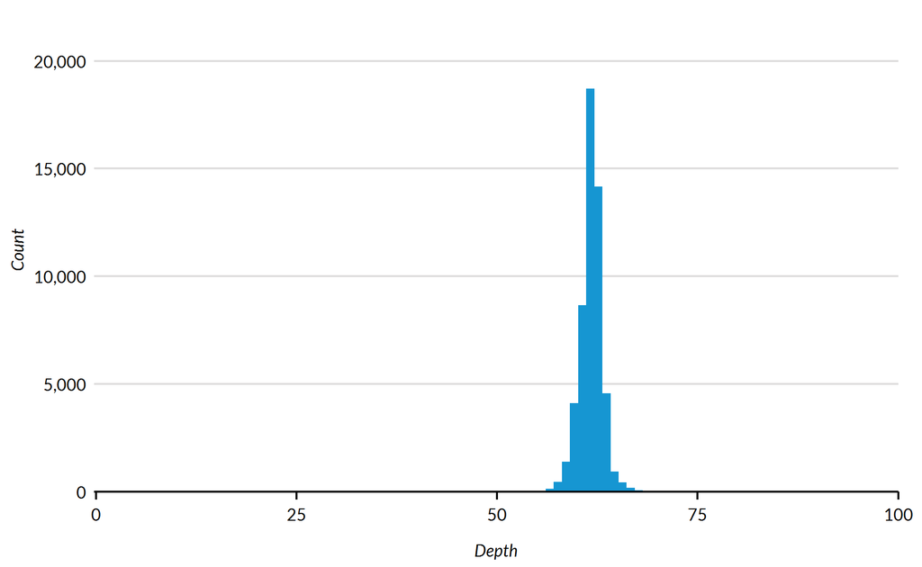

```r
ggplot(data = diamonds, mapping = aes(x = depth)) +
  geom_histogram(bins = 100) +
  scale_x_continuous(expand = expand_scale(mult = c(0.002, 0)),
                     limits = c(0, 100)) +
  scale_y_continuous(expand = expand_scale(mult = c(0, 0.2)), labels = scales::comma) +
  labs(x = "Depth",
       y = "Count")
```

### Boxplots

Boxplots were invented in the 1970s by John Tukey[^1]. Instead of showing the underlying data or binned counts of the underlying data, they focus on important values like the 25th percentile, median, and 75th percentile.

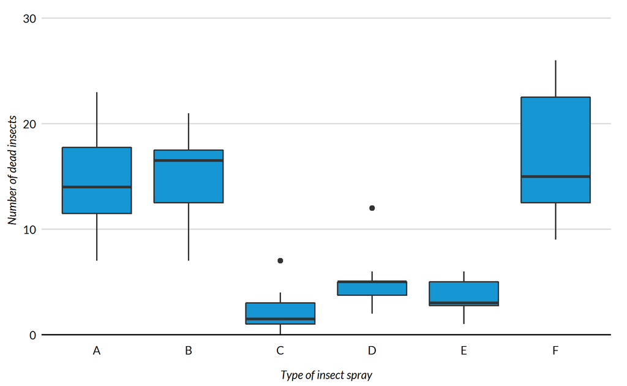

```r
InsectSprays %>%
  ggplot(mapping =  aes(x = spray, y = count)) +
  geom_boxplot() +
  scale_y_continuous(expand = expand_scale(mult = c(0, 0.2))) +
  labs(x = "Type of insect spray",
       y = "Number of dead insects") +
  remove_ticks()
```

### Smoothed Kernel Density Plots

Continuous variables with smooth distributions are sometimes better represented with smoothed kernel density estimates than histograms or boxplots. `geom_density()` computes and plots a kernel density estimate. Notice the lumps around integers and halves in the following distribution because of rounding.

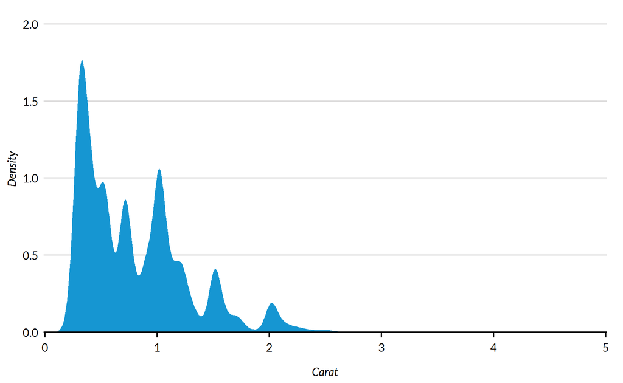

```r
diamonds %>%
  ggplot(mapping = aes(carat)) +
  geom_density(color = NA) +
  scale_x_continuous(expand = expand_scale(mult = c(0.002, 0)),
                     limits = c(0, NA)) +
  scale_y_continuous(expand = expand_scale(mult = c(0, 0.2))) +
  labs(x = "Carat",
       y = "Density")
```

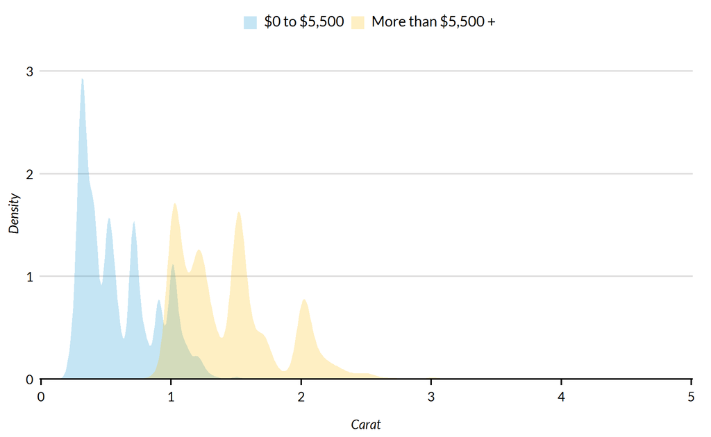

```r
diamonds %>%
  mutate(cost = ifelse(price > 5500, "More than $5,500 +", "$0 to $5,500")) %>%
  ggplot(mapping = aes(carat, fill = cost)) +
  geom_density(alpha = 0.25, color = NA) +
  scale_x_continuous(expand = expand_scale(mult = c(0.002, 0)),
                     limits = c(0, NA)) +
  scale_y_continuous(expand = expand_scale(mult = c(0, 0.1))) +
  labs(x = "Carat",
       y = "Density")
```

### Ridgeline Plots

Ridgeline plots are partially overlapping smoothed kernel density plots faceted by a categorical variable that pack a lot of information into one elegant plot.

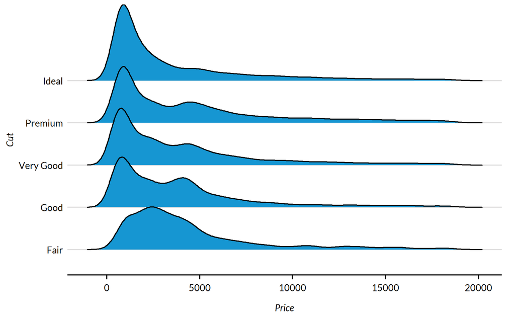

```r
library(ggridges)

ggplot(diamonds, mapping = aes(x = price, y = cut)) +
  geom_density_ridges(fill = "#1696d2") +
  labs(x = "Price",
       y = "Cut")
```

### Violin Plots

Violin plots are symmetrical displays of smooth kernel density plots.

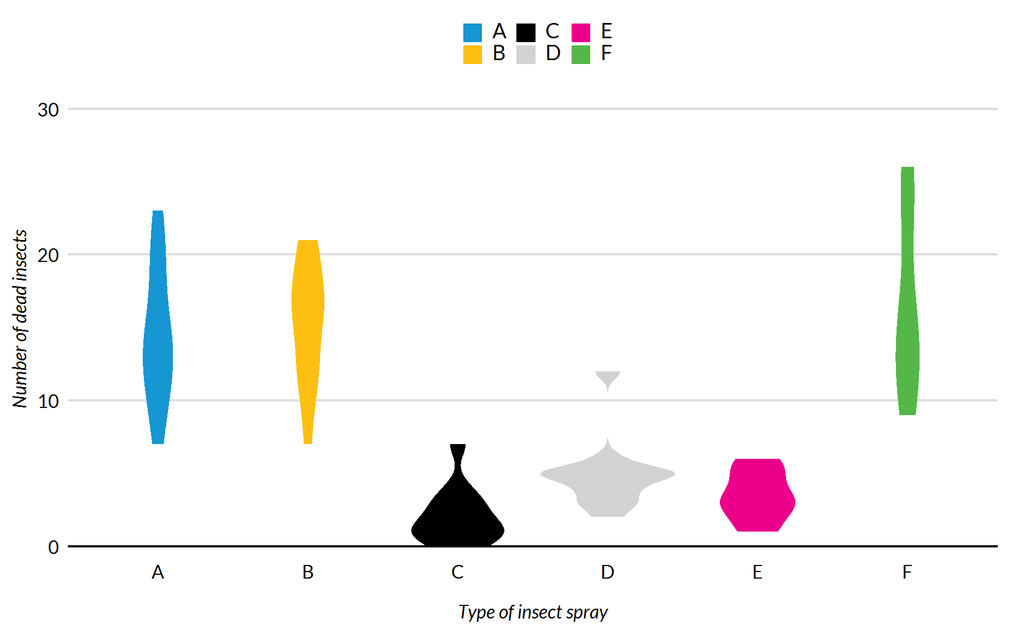

```r
InsectSprays %>%
  ggplot(mapping = aes(x = spray, y = count, fill = spray)) +
  geom_violin(color = NA) +
  scale_y_continuous(expand = expand_scale(mult = c(0, 0.2))) +
  labs(x = "Type of insect spray",
       y = "Number of dead insects") +
  remove_ticks()
```

### Bean Plot

Individual outliers and important summary values are not visible in violin plots or smoothed kernel density plots. Bean plots, [created by Peter Kampstra in 2008](https://www.jstatsoft.org/article/view/v028c01), are violin plots with data shown as small lines in a one-dimensional sstrip plot and larger lines for the mean.

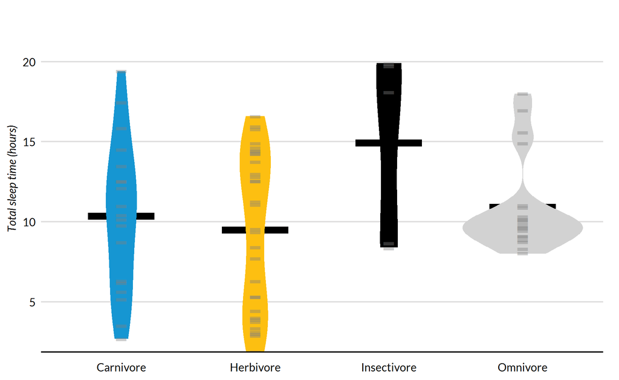

```r
msleep %>%
  filter(!is.na(vore)) %>%
  mutate(vore = fct_recode(vore,
                            "Insectivore" = "insecti",
                            "Omnivore" = "omni",
                            "Herbivore" = "herbi",
                            "Carnivore" = "carni"
                            )) %>%
  ggplot(aes(x = vore, y = sleep_total, fill = vore)) +
  stat_summary(fun.y = "mean",
               colour = "black",
               size = 30,
               shape = 95,
               geom = "point") +
  geom_violin(color = NA) +
  geom_jitter(width = 0,
              height = 0.05,
              alpha = 0.4,
              shape = "-",
              size = 10,
              color = "grey50") +
  scale_y_continuous(expand = expand_scale(mult = c(0, 0.2))) +
    labs(x = NULL,
         y = "Total sleep time (hours)") +
  theme(legend.position = "none") +
  remove_ticks()
```